# Project Introduction: Car Make and Model Recognition System

## 1. Data Requirements Documentation

### Purpose of the Documentation

This documentation serves as a comprehensive guide for managing and utilizing data in the development of a car make and model recognition system. It outlines the types of data needed, quality standards, and ethical considerations, ensuring that the project's goals are met effectively and responsibly.

### Data Elements

Each data element is crucial for a thorough understanding of the automotive industry and for conducting detailed analyses. Here's a breakdown of these elements:

#### Identify Data Types

1. **Numerical Data**
   - **Vehicle Year**:
     - **Description**: Year of manufacture of the vehicles.
     - **Units**: Year (e.g., 2012, 2020)
     - **Importance**: Critical for identifying the model year of the car.
     - **Source**: Automotive databases and car listings or websited like kaggle.
     - **Quality standards**: Years from the last 10 years and to use realistc years.
     - **Ethical Considerations**: All of the data is collected legaly and can be used in academic work.
     - **Project Relevance**: Essential for distinguishing between different generations of the same car model.
2. **Categorical Data**
   - **Car Make and Model**:
     - **Description**: The brand and specific model of the vehicle.
     - **Categories**: Various car brands and models (e.g., BMW M3, Tesla Model S).
     - **Importance**: Fundamental for the classification task of the project.
     - **Source**: Automotive databases, manufacturer websites and websites like kaggle.
     - **Quality Standards**: High accuracy in labeling the images and using real models.
     - **Ethical Considerations**: The data accured is open for the public and not classified.
     - **Project Relevance**: Core to the system’s capability to recognize and differentiate between various cars.
3. **Image Data**
   - **Car Images**:
     - **Description**: Photographs of cars from various angles.
     - **Resolution**: Resolutions atleast 400x400 or higher.
     - **Range**: Images covering a wide variety of car brands.
     - **Importance**: Vital for training the image recognition model.
     - **Source**: Online car databases, user-submitted images and websited like kaggle.
     - **Quality Standards**: Images that have a clear view of the car and images that are not blurry.
     - **Ethical Considerations**: Usage of images compliant with copyright laws.
     - **Project Relevance**: The primary data type used for training and testing the model.

## 2. Data Collection Process

### Overview

The data for this project is from Stanford Car Dataset.

### Collection Methodology

- **Download from webiste**:
  - The dataset was downloaded from kaggle.
- **Data Storage**:
  - Data was stored in an organized manner, with images categorized by make and model.
  - Metadata about each car (like make and year) was stored in corresponding CSV files.

### Compliance and Security

- **Data Protection**: Ensured all collected data complies with relevant data privacy and protection laws.
- **Usage Rights**: Ensured all images and data used are either publicly available or used with permission.

Here are all the needed libraries

```python
import os
import pandas as pd
import matplotlib.pyplot as plt
import seaborn as sns
import torch
import torch.nn as nn
import torch.optim as optim
from torchvision import datasets, models, transforms
from torch.utils.data import DataLoader
from sklearn.metrics import classification_report, accuracy_score
import cv2
from pathlib import Path
from shutil import move
import matplotlib.image as mpimg
import numpy as np
from torchvision.transforms import RandomErasing
import optuna
import random
from PIL import Image


# Check for CUDA
device = torch.device("cuda" if torch.cuda.is_available() else "cpu")
```

# Data Understanding

Here I am going to explore the Stanford Car Dataset and see it's content and infotmation about the characteristics of the images and make noted for futher visualization.

I will load the train and test directory.

```python
dataset_dir = './car_data'
train_dir = os.path.join(dataset_dir, 'train')
test_dir = os.path.join(dataset_dir, 'test')
```

I will start by checking the number of images contained in each directory, which represents a different car model. Seing what there average is, how many images there are and how many vehicle classes there are.

The count_images function is designed to traverse a specified directory and perform two primary tasks:

- Image Counting: It counts the number of image files within each subdirectory of the provided directory.
- Class Counting: It determines the number of unique classes, which are represented by the subdirectories.

```python
def count_images(directory):
    """Count the number of images in each subdirectory and the total number of unique classes."""
    total_images = 0
    subdirectories = os.listdir(directory)
    for subdir in subdirectories:
        subdir_path = os.path.join(directory, subdir)
        num_images = len([file for file in os.listdir(subdir_path) if os.path.isfile(os.path.join(subdir_path, file))])
        total_images += num_images
        print(f"{subdir}: {num_images} images")
    return subdirectories, total_images
```

```python
# Count images in the training directory
train_classes, total_train_images = count_images(train_dir)
print(f"Total number of vehicle classes in training set: {len(train_classes)}")
print(f"Total number of images in training set: {total_train_images}")
print(f"Average number of images per vehicle class in training set: {total_train_images / len(train_classes):.2f}")
```

```
Acura Integra Type R 2001: 44 images
Acura RL Sedan 2012: 32 images
Acura TL Sedan 2012: 43 images
Acura TL Type-S 2008: 41 images
Acura TSX Sedan 2012: 41 images
Acura ZDX Hatchback 2012: 39 images
AM General Hummer SUV 2000: 43 images
Aston Martin V8 Vantage Convertible 2012: 45 images
Aston Martin V8 Vantage Coupe 2012: 41 images
Aston Martin Virage Convertible 2012: 31 images
Aston Martin Virage Coupe 2012: 35 images
Audi 100 Sedan 1994: 41 images
Audi 100 Wagon 1994: 42 images
Audi A5 Coupe 2012: 41 images
Audi R8 Coupe 2012: 43 images
Audi RS 4 Convertible 2008: 37 images
Audi S4 Sedan 2007: 45 images
Audi S4 Sedan 2012: 39 images
Audi S5 Convertible 2012: 42 images
Audi S5 Coupe 2012: 43 images
Audi S6 Sedan 2011: 46 images
Audi TT Hatchback 2011: 41 images
Audi TT RS Coupe 2012: 40 images
Audi TTS Coupe 2012: 43 images
Audi V8 Sedan 1994: 44 images
Bentley Arnage Sedan 2009: 39 images
Bentley Continental Flying Spur Sedan 2007: 45 images
Bentley Continental GT Coupe 2007: 46 images
Bentley Continental GT Coupe 2012: 35 images
Bentley Continental Supersports Conv. Convertible 2012: 37 images
Bentley Mulsanne Sedan 2011: 36 images
BMW 1 Series Convertible 2012: 35 images
BMW 1 Series Coupe 2012: 41 images
BMW 3 Series Sedan 2012: 43 images
BMW 3 Series Wagon 2012: 42 images
BMW 6 Series Convertible 2007: 43 images
BMW ActiveHybrid 5 Sedan 2012: 34 images
BMW M3 Coupe 2012: 43 images
BMW M5 Sedan 2010: 40 images
BMW M6 Convertible 2010: 41 images
```

[output cut: 144 more lines]

```
Suzuki SX4 Sedan 2012: 41 images
Tesla Model S Sedan 2012: 38 images
Toyota 4Runner SUV 2012: 40 images
Toyota Camry Sedan 2012: 44 images
Toyota Corolla Sedan 2012: 43 images
Toyota Sequoia SUV 2012: 38 images
Volkswagen Beetle Hatchback 2012: 42 images
Volkswagen Golf Hatchback 1991: 46 images
Volkswagen Golf Hatchback 2012: 43 images
Volvo 240 Sedan 1993: 46 images
Volvo C30 Hatchback 2012: 41 images
Volvo XC90 SUV 2007: 42 images
Total number of vehicle classes in training set: 196
Total number of images in training set: 8058
Average number of images per vehicle class in training set: 41.11
```

```python
# Count images in the testing directory
test_classes, total_test_images = count_images(test_dir)
print(f"Total number of vehicle classes in testing set: {len(test_classes)}")
print(f"Total number of images in testing set: {total_test_images}")
print(f"Average number of images per vehicle class in testing set: {total_test_images / len(test_classes):.2f}")
```

```
Acura Integra Type R 2001: 42 images
Acura RL Sedan 2012: 32 images
Acura TL Sedan 2012: 43 images
Acura TL Type-S 2008: 41 images
Acura TSX Sedan 2012: 40 images
Acura ZDX Hatchback 2012: 39 images
AM General Hummer SUV 2000: 44 images
Aston Martin V8 Vantage Convertible 2012: 45 images
Aston Martin V8 Vantage Coupe 2012: 41 images
Aston Martin Virage Convertible 2012: 33 images
Aston Martin Virage Coupe 2012: 38 images
Audi 100 Sedan 1994: 40 images
Audi 100 Wagon 1994: 42 images
Audi A5 Coupe 2012: 41 images
Audi R8 Coupe 2012: 42 images
Audi RS 4 Convertible 2008: 36 images
Audi S4 Sedan 2007: 45 images
Audi S4 Sedan 2012: 39 images
Audi S5 Convertible 2012: 42 images
Audi S5 Coupe 2012: 42 images
Audi S6 Sedan 2011: 46 images
Audi TT Hatchback 2011: 40 images
Audi TT RS Coupe 2012: 38 images
Audi TTS Coupe 2012: 42 images
Audi V8 Sedan 1994: 43 images
Bentley Arnage Sedan 2009: 38 images
Bentley Continental Flying Spur Sedan 2007: 44 images
Bentley Continental GT Coupe 2007: 46 images
Bentley Continental GT Coupe 2012: 34 images
Bentley Continental Supersports Conv. Convertible 2012: 36 images
Bentley Mulsanne Sedan 2011: 35 images
BMW 1 Series Convertible 2012: 35 images
BMW 1 Series Coupe 2012: 41 images
BMW 3 Series Sedan 2012: 41 images
BMW 3 Series Wagon 2012: 41 images
BMW 6 Series Convertible 2007: 44 images
BMW ActiveHybrid 5 Sedan 2012: 34 images
BMW M3 Coupe 2012: 43 images
BMW M5 Sedan 2010: 41 images
BMW M6 Convertible 2010: 40 images
```

[output cut: 144 more lines]

```
Suzuki SX4 Sedan 2012: 40 images
Tesla Model S Sedan 2012: 37 images
Toyota 4Runner SUV 2012: 40 images
Toyota Camry Sedan 2012: 43 images
Toyota Corolla Sedan 2012: 43 images
Toyota Sequoia SUV 2012: 37 images
Volkswagen Beetle Hatchback 2012: 41 images
Volkswagen Golf Hatchback 1991: 46 images
Volkswagen Golf Hatchback 2012: 43 images
Volvo 240 Sedan 1993: 45 images
Volvo C30 Hatchback 2012: 39 images
Volvo XC90 SUV 2007: 43 images
Total number of vehicle classes in testing set: 196
Total number of images in testing set: 7959
Average number of images per vehicle class in testing set: 40.61
```

##### Lets break down the results.

```python
def augment_images(image_folder, class_name, target_count):
    transform = transforms.Compose([
        transforms.RandomHorizontalFlip(),
        transforms.RandomRotation(15),
        transforms.ColorJitter(brightness=0.5, contrast=0.5, saturation=0.5),
    ])

    class_path = os.path.join(image_folder, class_name)
    images = [os.path.join(class_path, img) for img in os.listdir(class_path)]
    num_images = len(images)

    while num_images < target_count:
        img_path = random.choice(images)
        img = Image.open(img_path)
        new_img = transform(img)

        new_img_path = os.path.join(class_path, f"aug_{num_images}.jpg")
        new_img.save(new_img_path)

        num_images += 1

augment_images('./car_data/train','Hyundai Accent Sedan 2012', 20)
```

This code is designed to process a directory structure containing images of cars, where each subdirectory is named in a 'Year Make Model' format, indicating the year, make, and model of the car. It collects information about the number of images available for each car model and organizes this data into a structured format using a pandas DataFrame. Let's break down the code.

```python
#each folder name is in the 'Year Make Model' format
def extract_info_from_folder(folder_name):
    parts = folder_name.split()
    year = parts[-1]  # The last part is the year
    make = parts[0]   # The first part is the make
    model = ' '.join(parts[1:-1])  # The middle part(s) is/are the model
    return year, make, model

# Path to the dataset directories
train_dir = './car_data/train'
test_dir = './car_data/test'

# Initialize a list to hold the data
data = []

# Function to process a directory and append data
def process_directory(directory):
    for folder_name in os.listdir(directory):
        year, make, model = extract_info_from_folder(folder_name)
        image_count = len([file for file in os.listdir(os.path.join(directory, folder_name)) if os.path.isfile(os.path.join(directory, folder_name, file))])
        data.append({'Year': year, 'Make': make, 'Model': model, 'ImageCount': image_count})

# Process both training and testing directories
process_directory(train_dir)
process_directory(test_dir)

# Convert the list to a pandas DataFrame
df = pd.DataFrame(data)

image_counts = df.groupby(['Make', 'Model', 'Year'])['ImageCount'].sum().reset_index()
```

Now I am going to check if there is a pattern or trend of the number of images based on the year and model of the vehicles.

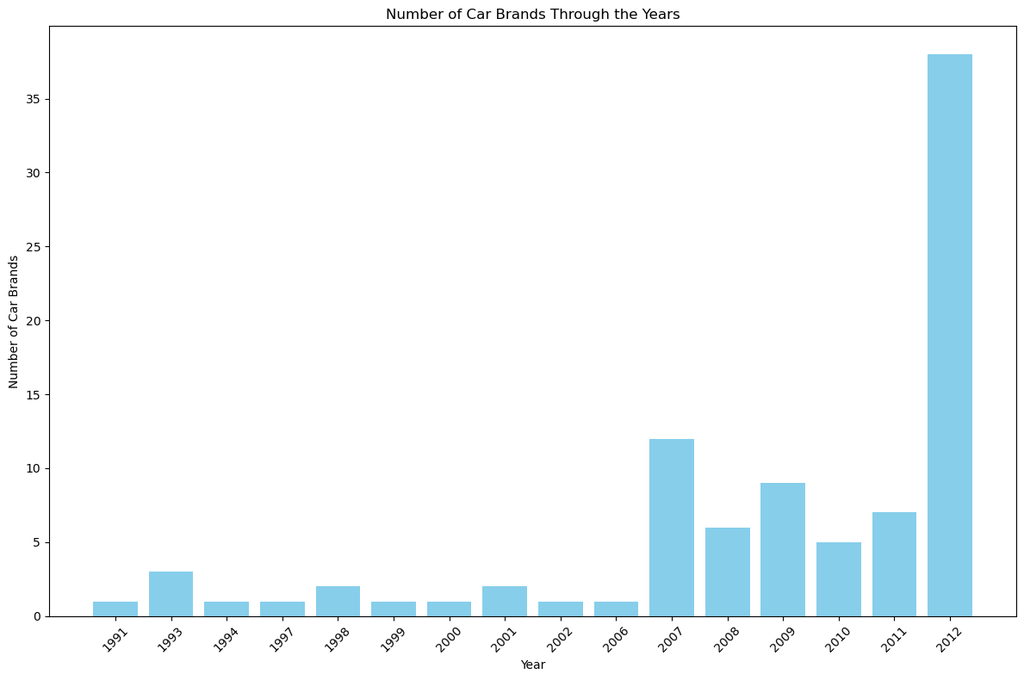

```python
# Group by 'Year' and count unique 'Make' entries
year_make_count = df.groupby('Year')['Make'].nunique().reset_index(name='BrandCount')

# Sort the DataFrame by 'Year'
year_make_count_sorted = year_make_count.sort_values('Year')

# Plot bar chart
plt.figure(figsize=(12, 8))
plt.bar(year_make_count_sorted['Year'], year_make_count_sorted['BrandCount'], color='skyblue')
plt.title('Number of Car Brands Through the Years')
plt.xlabel('Year')
plt.ylabel('Number of Car Brands')
plt.xticks(rotation=45)
plt.tight_layout()
plt.show()
```

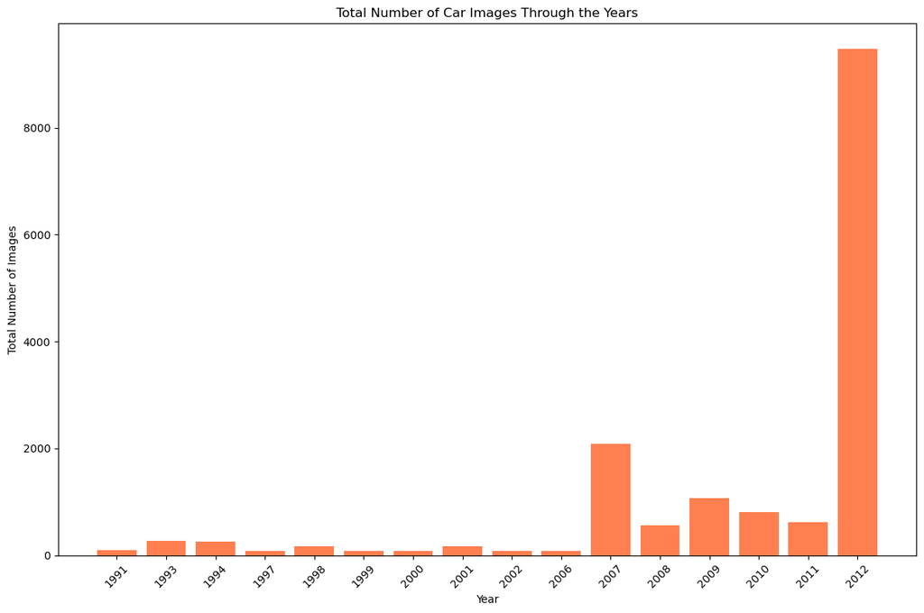

```python
# Group by 'Year' and sum 'ImageCount' entries
year_image_count = df.groupby('Year')['ImageCount'].sum().reset_index(name='TotalImages')

# Sort the DataFrame by 'Year'
year_image_count_sorted = year_image_count.sort_values('Year')

# Plot bar chart for Total Images per Year
plt.figure(figsize=(12, 8))
plt.bar(year_image_count_sorted['Year'], year_image_count_sorted['TotalImages'], color='coral')
plt.title('Total Number of Car Images Through the Years')
plt.xlabel('Year')
plt.ylabel('Total Number of Images')
plt.xticks(rotation=45)
plt.tight_layout()
plt.show()
```

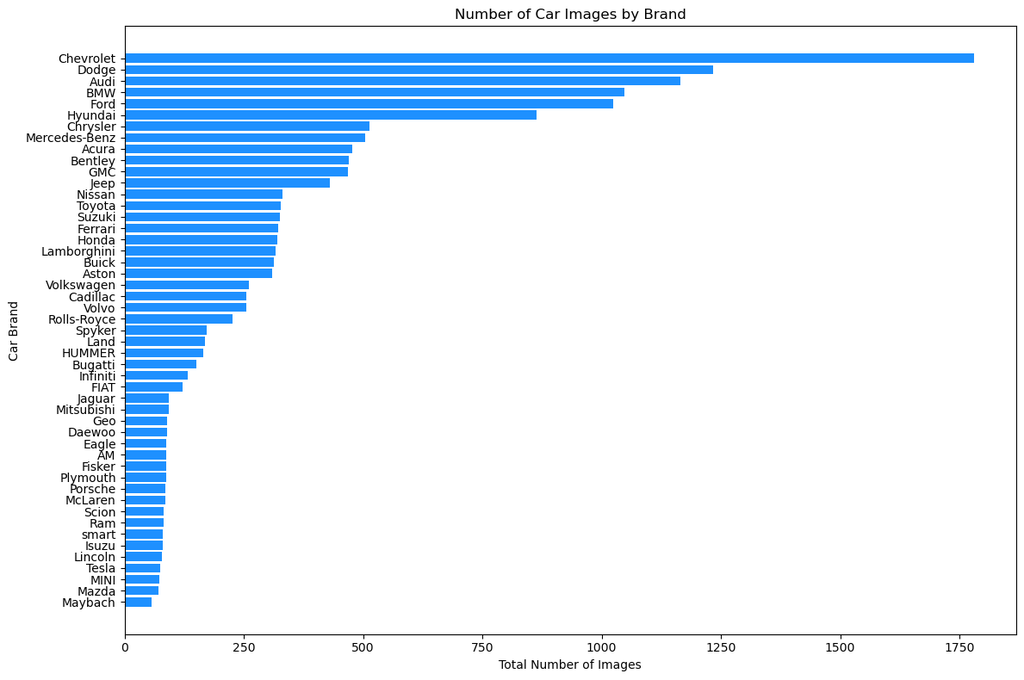

```python
brand_count = df.groupby('Make')['ImageCount'].sum().reset_index(name='Total')

# Sort the DataFrame by 'Total' in descending order
brand_count_sorted = brand_count.sort_values('Total', ascending=True)

# Plot horizontal bar chart
plt.figure(figsize=(12, 8))
plt.barh(brand_count_sorted['Make'], brand_count_sorted['Total'], color='dodgerblue')
plt.title('Number of Car Images by Brand')
plt.xlabel('Total Number of Images')
plt.ylabel('Car Brand')
plt.tight_layout()

plt.show()
```

The bar chart showcases the distribution of car images by brand within the dataset. It is evident that certain brands, such as Chevrolet, Dodge, and Audi, have a notably larger number of images compared to others. This could imply a richer availability of images for these brands or perhaps a specific focus on these brands when the image collection was being assembled. The discrepancy in image quantity between brands may also reflect their market presence or popularity, with some brands releasing more models or being more widely photographed than others. The chart indicates a varied representation of brands, with a few brands dominating the image count, suggesting potential areas of focus for further image collection to balance the representation across all brands.

Now the different brands will be checked to see how much of the cars are from the year 2012.

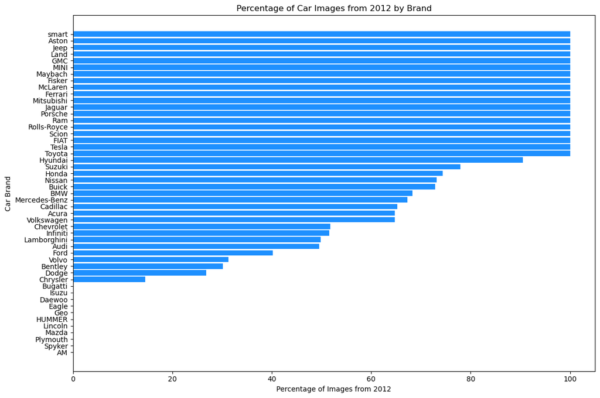

```python
# Filter the DataFrame for the year 2012
df_2012 = df[df['Year'] == '2012']

# Group by 'Make' and sum 'ImageCount' entries for the year 2012
brand_count_2012 = df_2012.groupby('Make')['ImageCount'].sum().reset_index(name='Total2012')

# Merge with the total counts to get the proportion of 2012 images per brand
brand_count_total = df.groupby('Make')['ImageCount'].sum().reset_index(name='Total')
brand_count_merged = pd.merge(brand_count_total, brand_count_2012, on='Make', how='left').fillna(0)

# Calculate the percentage of 2012 images for each brand
brand_count_merged['Percentage2012'] = (brand_count_merged['Total2012'] / brand_count_merged['Total']) * 100

# Sort the DataFrame by 'Percentage2012' in descending order
brand_count_merged_sorted = brand_count_merged.sort_values('Percentage2012', ascending=True)

# Plot horizontal bar chart
plt.figure(figsize=(12, 8))
plt.barh(brand_count_merged_sorted['Make'], brand_count_merged_sorted['Percentage2012'], color='dodgerblue')
plt.title('Percentage of Car Images from 2012 by Brand')
plt.xlabel('Percentage of Images from 2012')
plt.ylabel('Car Brand')
plt.tight_layout()
plt.show()
```

This bar chart illustrates the proportion of car images from 2012 for each brand within the dataset. Notably, certain brands such as Smart, Aston, Jeep, and Land display a high percentage of their images from this specific year, indicating that the dataset may have a particular emphasis on models from 2012 for these brands. On the other hand, brands like AM, Spyker, Mazda, and HUMMER have a much lower relative representation of 2012 images, which could be due to various reasons such as fewer releases in that year, limited availability of images, or a focus on other years for those brands. The variance in the percentage of images from 2012 suggests that while the dataset has a substantial representation of this year, the distribution is not uniform across all brands. This might reflect the data collection process's responsiveness to the availability of images or a particular interest in the models released in 2012.

Since there is no outside information of the methods used to collect the data and the reasoning behind it, I state that there is no connection between the given images and the released year.

Now, a pie chart will be created to visualize the distribution of car brands within the entire collection of images. This chart will help us see which brands are more common in the dataset by turning the number of images for each brand into a slice of the pie. There is a high number of brands that are below 2% and make the piechart cluttered thats why I put them all under one naming "Other".

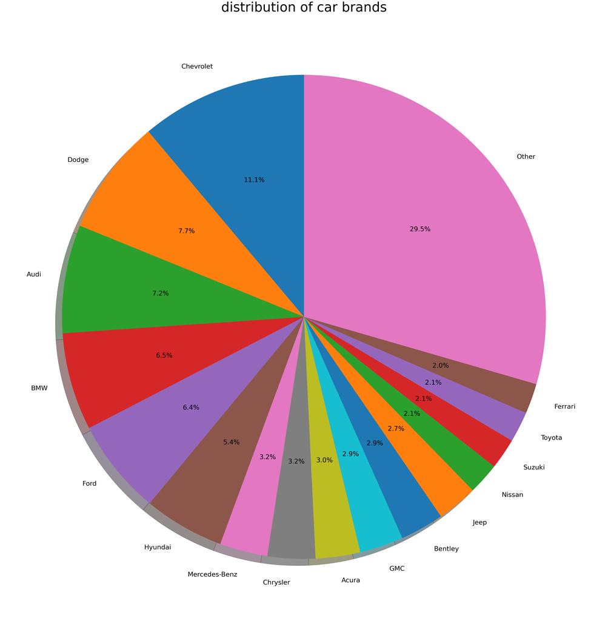

```python
# Calculate the total number of images
total_images = df['ImageCount'].sum()

# Calculate the image count for each make
make_image_counts = df.groupby('Make')['ImageCount'].sum().sort_values(ascending=False)

# Create a threshold for 2% of the total image count
threshold = total_images * 0.02

# Filter makes that have less than the threshold
small_makes = make_image_counts[make_image_counts < threshold]

# Combine small makes into a single 'Other' category
make_image_counts = make_image_counts[make_image_counts >= threshold]
make_image_counts['Other'] = small_makes.sum()

# Plotting the distribution of car makes in the dataset
f, ax = plt.subplots(1, 1, figsize=(50, 50))
make_image_counts.plot.pie(shadow=True, fontsize=30, autopct='%1.1f%%', startangle=90)
plt.title("distribution of car brands", fontsize=60)
plt.ylabel('')
plt.show()
```

There is a significant imbalance in the number of images per car make, as indicated by the pie chart, can lead to biased machine learning models. If a model is trained on this data, it may perform well on car makes with a higher representation (like those with larger slices of the pie) but poorly on underrepresented ones (included in the "Other" category).

Since the dataset contains around 16000 images there might be some which are blurry and this might lower the accuracy of the machine learning model. The following code will take care of that. Using cv2 which is a open-source computer vision and machine learning software library used for image processing, I will try to find blurry images and move them to a seperate folder.

```
Total moved from train: 86
Total moved from test: 82
```

[figure not shown]

```python
# Set the threshold for blur detection
blur_threshold = 100

def is_blurry(image_path, threshold=blur_threshold):
    image = cv2.imread(str(image_path))
    gray = cv2.cvtColor(image, cv2.COLOR_BGR2GRAY)
    laplacian = cv2.Laplacian(gray, cv2.CV_64F)
    laplacian_variance = laplacian.var()
    return laplacian_variance < threshold

def move_blurry_images(directory_path, destination_base_folder="blurry", sample_limit=10):
    moved_count = 0
    sample_images = []
    car_names = []

    # Create base blurry folder
    blurry_base_folder_path = Path(destination_base_folder)
    blurry_base_folder_path.mkdir(exist_ok=True)

    for brand_folder in directory_path.iterdir():
        if brand_folder.is_dir():
            # Create brand specific folder inside blurry base folder
            blurry_folder_path = blurry_base_folder_path / directory_path.name / brand_folder.name
            blurry_folder_path.mkdir(parents=True, exist_ok=True)

            for image_path in brand_folder.glob("*.[jJ][pP][gG]"):
                if is_blurry(image_path):
                    move(str(image_path), str(blurry_folder_path / image_path.name))
                    moved_count += 1

                    if len(sample_images) < sample_limit:
                        sample_images.append(str(blurry_folder_path / image_path.name))
                        car_names.append(brand_folder.stem)

    print(f"Total moved from {directory_path.name}: {moved_count}")
    return sample_images, car_names

# path to image datasets
train_path = Path('./car_data/train')
test_path = Path('./car_data/test')

# Move blurry images and get sample image paths for both train and test datasets
train_samples, train_car_names = move_blurry_images(train_path)
test_samples, test_car_names = move_blurry_images(test_path)

# Combine samples and car names from both train and test datasets
all_samples = train_samples + test_samples
all_car_names = train_car_names + test_car_names

# Adjust the subplot size based on the number of images
num_samples = len(all_samples)
cols = 5
rows = num_samples // cols + (num_samples % cols > 0)

# Display sample blurry images from both train and test datasets
plt.figure(figsize=(15, rows * 3))
for i, img_path in enumerate(all_samples):
    img = mpimg.imread(img_path)
    plt.subplot(rows, cols, i + 1)
    plt.imshow(img)
    plt.title(all_car_names[i])
    plt.axis('off')
plt.tight_layout()
plt.show()
```

These here are some of the blurry images that have been removed from the training and test data.

# Preprocessing

In this step, I will prepare the images for the machine learning algorithm. This includes several transformation processes designed to both standardize the input data and augment the training dataset to improve generalization of the model.

#### Train Transformations

Resize:

- transforms.Resize((400, 400)): This transformation resizes each image to a fixed size of 400x400 pixels. This uniformity is crucial because neural networks typically require inputs of the same dimensions.

Random Horizontal Flip:

- transforms.RandomHorizontalFlip(): This applies a random horizontal flip to the images. With a default probability of 50%, it mirrors the image along the vertical axis. This randomization increases the diversity of the training data, helping to prevent overfitting and improve the model's generalization.

Random Rotation:

- transforms.RandomRotation(15): This rotates the image by a random angle within ±15 degrees. This slight rotation adds variety to the training dataset, further aiding the model's ability to generalize.

ToTensor:

- transforms.ToTensor(): Converts the image to a PyTorch tensor, changing the image from a range of 0-255 to 0-1 (normalizing pixel values).

Normalize:

- transforms.Normalize([0.485, 0.456, 0.406], [0.229, 0.224, 0.225]): This standardizes the pixel values across the dataset. The first list of numbers is the mean for each channel (RGB), and the second list is the standard deviation. This normalization helps in stabilizing the learning process.

ColorJitter:

- transforms.ColorJitter(brightness=0.2, contrast=0.2, saturation=0.2, hue=0.1): This transformation randomly changes the brightness, contrast, saturation, and hue of the image. The parameters (0.2 for brightness, contrast, saturation, and 0.1 for hue) specify how much each attribute can vary. Adjusting these image attributes can make the model more robust to lighting changes and color variations in different environments.

RandomCrop:

- transforms.RandomCrop(350): This transformation randomly crops the image to a size of 350x350 pixels. Cropping is done after resizing the image to 400x400 pixels, which means the crop will take a portion from the original image, adding variability to the position of the objects in the image. This can help the model learn to recognize objects regardless of their position within the image frame.

```python
train_transforms = transforms.Compose([
    transforms.Resize((400, 400)),
    transforms.RandomHorizontalFlip(),
    transforms.RandomRotation(15),
    transforms.ColorJitter(brightness=0.2, contrast=0.2, saturation=0.2, hue=0.1),
    transforms.RandomCrop(350),
    transforms.ToTensor(),
    transforms.Normalize([0.485, 0.456, 0.406], [0.229, 0.224, 0.225])
])
```

#### Resizing:

All images are resized to a consistent dimension of 400x400 pixels. This standardization is crucial for neural network models to process batches of images efficiently.

#### Test Transformations

For the test dataset, the transformations are simpler, as we do not need the randomization used in training:

Resize:

- The same resizing is applied to ensure the test images match the input size expected by the model. ToTensor and Normalize:

The same conversion to a tensor and normalization are applied for consistency with the training data.

```python
test_transforms = transforms.Compose([
    transforms.Resize((400, 400)),
    transforms.ToTensor(),
    transforms.Normalize([0.485, 0.456, 0.406], [0.229, 0.224, 0.225])
])
```

# Splitting into Train/Test

At this stage, we are preparing our image data for the machine learning model. The process involves organizing the images into training and testing datasets. This separation is crucial for training the model and then evaluating its performance on unseen data.

```python
# Loading datasets
train_dataset = datasets.ImageFolder(os.path.join(dataset_dir, 'train'), transform=train_transforms)
train_loader = DataLoader(train_dataset, batch_size=32, shuffle=True, num_workers=4)

test_dataset = datasets.ImageFolder(os.path.join(dataset_dir, 'test'), transform=test_transforms)
test_loader = DataLoader(test_dataset, batch_size=32, shuffle=False, num_workers=4)
```

Loading Datasets:

- train_dataset and test_dataset are created from the images in the respective directories. These datasets will be used to train and test the model. transform=train_transforms and transform=test_transforms are applied to the images, ensuring they are in the correct format for the model.

```python
train_dataset = datasets.ImageFolder(os.path.join(dataset_dir, 'train'), transform=train_transforms)
test_dataset = datasets.ImageFolder(os.path.join(dataset_dir, 'test'), transform=test_transforms)
```

Creating DataLoaders:

- DataLoader is a utility that creates an iterable over these datasets. For the training data (train_loader), we shuffle the data (to ensure the model doesn't learn any order-based biases) and set the batch size to 32. This means the model will see 32 images at a time during training. For the testing data (test_loader), shuffling is not necessary. The batch size is also set to 32 for consistency.

```python
train_loader = DataLoader(train_dataset, batch_size=32, shuffle=True, num_workers=4)
test_loader = DataLoader(test_dataset, batch_size=32, shuffle=False, num_workers=4)
```

# Modelling

Model Setup:

- We start by loading a pre-trained ResNet-34 model, a deep convolutional neural network known for its high accuracy in image classification tasks. The num_ftrs line adjusts the model to fit our specific dataset by modifying the final layer to predict the number of classes in our training set.

```python
model = models.resnet34(pretrained=True)
num_ftrs = model.fc.in_features
model.fc = nn.Linear(num_ftrs, len(train_dataset.classes))
model = model.to(device)
```

##### Hyperparameters

Now I will use Optuna, a hyperparameter optimization framework that intelligently navigates through vast parameter. The code was already executed and the best hyperparameter results were applid in the function because it takes a long time to run it(31 hours). These are the parameters set to the best value based on the Optuna results

- lr (learning rate) is set to approximately 0.051. The learning rate is one of the most important hyperparameters in training neural networks. It controls the size of the steps the optimizer takes while adjusting the weights in the network.
- momentum is a hyperparameter that helps accelerate the optimizer in the relevant direction and dampens oscillations. It's set to approximately 0.547.
- step_size is set to 8. This value is assosiated with the learning rate scheduler ('StepLR'). The scheduler changes the learning rate according to a pre-defined schedule, which is critical in avoiding local minima and improving convergence.
- gamma - In the context of the StepLR scheduler, gamma is the factor by which the learning rate will be multiplied after every step_size epochs. The best value is 0.2298444814148019.

The code here is used to optimize the model's performance by fine-tuning key hyperparameters, such as learning rate and momentum, through Optuna. This is achieved by iteratively training the model and evaluating its performance across different hyperparameter combinations, allowing for the identification and application of the most effective settings for the given dataset and task.

```python
def objective(trial):
    # range of values for the hyperparameters
    lr = trial.suggest_float("lr", 1e-5, 1e-1, log=True)
    momentum = trial.suggest_float("momentum", 0.4, 0.9)
    step_size = trial.suggest_int("step_size", 1, 10)
    gamma = trial.suggest_float("gamma", 0.1, 0.9)

    # Load a pre-trained ResNet-34 model and modify it for our dataset
    model = models.resnet34(pretrained=True)
    num_ftrs = model.fc.in_features
    model.fc = nn.Linear(num_ftrs, len(train_dataset.classes))
    model = model.to(device)

    criterion = nn.CrossEntropyLoss()
    optimizer = optim.SGD(model.parameters(), lr=lr, momentum=momentum)
    scheduler = optim.lr_scheduler.StepLR(optimizer, step_size=step_size, gamma=gamma)

    return train_model(model, criterion, optimizer, scheduler, trial)

# Function to train the model
def train_model(model, criterion, optimizer, scheduler, trial, num_epochs=10):
    for epoch in range(num_epochs):
        model.train()
        running_loss = 0.0
        running_corrects = 0

        for inputs, labels in train_loader:
            inputs = inputs.to(device)
            labels = labels.to(device)

            optimizer.zero_grad()

            with torch.set_grad_enabled(True):
                outputs = model(inputs)
                loss = criterion(outputs, labels)
                _, preds = torch.max(outputs, 1)
                loss.backward()
                optimizer.step()

            running_loss += loss.item() * inputs.size(0)
            running_corrects += torch.sum(preds == labels.data)

        scheduler.step()

        epoch_loss = running_loss / len(train_loader.dataset)
        epoch_acc = running_corrects.double() / len(train_loader.dataset)

        trial.report(epoch_acc, epoch)

        if trial.should_prune():
            raise optuna.exceptions.TrialPruned()

    return epoch_acc

study = optuna.create_study(direction="maximize")
study.optimize(objective, n_trials=20)

print("Best hyperparameters: ", study.best_trial.params)
```

Now, I will apply the optimized parameters to the model using nn.CrossEntropyLoss() and optim.SGD.

- nn.CrossEntropyLoss() is ideal for our multi-class classification problem as it efficiently combines log softmax and negative log likelihood loss, ensuring accurate probability distribution predictions. The chosen optim.SGD optimizer, with a learning rate of 0.05116282512153675 and momentum of 0.5470364990595213, as determined by Optuna, optimally updates the model's weights, while the StepLR scheduler adjusts the learning rate to enhance convergence as training progresses."

```python
criterion = nn.CrossEntropyLoss()
optimizer = optim.SGD(model.parameters(), lr=0.05116282512153675, momentum=0.5470364990595213)
scheduler = optim.lr_scheduler.StepLR(optimizer, step_size=8, gamma=0.2298444814148019)
```

# Evaluation

After setting up the model, we need to evaluate its performance. This involves running the model on the test dataset and measuring its accuracy and other metrics.

Training Function:

- The train_model function trains the model over a specified number of epochs. During each epoch, it iterates over the training data, computes the loss, and updates the model's weights. It also prints the loss and accuracy for each epoch, which helps us monitor the training process.

```python
def train_model(model, criterion, optimizer, scheduler, num_epochs=10):
    train_losses = []
    train_accuracies = []

    for epoch in range(num_epochs):
        model.train()
        running_loss = 0.0
        running_corrects = 0

        for inputs, labels in train_loader:
            inputs = inputs.to(device)
            labels = labels.to(device)
            optimizer.zero_grad()

            outputs = model(inputs)
            loss = criterion(outputs, labels)
            _, preds = torch.max(outputs, 1)
            loss.backward()
            optimizer.step()

            running_loss += loss.item() * inputs.size(0)
            running_corrects += torch.sum(preds == labels.data).item()

        scheduler.step()
        epoch_loss = running_loss / len(train_loader.dataset)
        epoch_acc = running_corrects / len(train_loader.dataset)

        train_losses.append(epoch_loss)
        train_accuracies.append(epoch_acc)

        print('Epoch {}/{} - Loss: {:.4f} - Acc: {:.4f}'.format(
            epoch, num_epochs - 1, epoch_loss, epoch_acc))

    plt.figure(figsize=(10, 5))
    plt.plot(train_losses, label='Training Loss')
    plt.plot(train_accuracies, label='Training Accuracy')
    plt.xlabel('Epochs')
    plt.ylabel('Loss/Accuracy')
    plt.title('Training Performance')
    plt.legend()
    plt.show()

    return model
```

Evaluation Function:

- The evaluate_model function assesses the model's performance on the test data. It calculates the loss and accuracy and also provides a classification report, which includes metrics like precision, recall, and F1-score. It returns the accuracy score, which is a key metric to understand how well the model performs on unseen data.

```python
def evaluate_model(model, test_loader, criterion, device, test_dataset):
    model.eval()
    all_preds = []
    all_labels = []
    running_loss = 0.0
    running_corrects = 0

    with torch.no_grad():
        for inputs, labels in test_loader:
            inputs = inputs.to(device)
            labels = labels.to(device)

            outputs = model(inputs)
            loss = criterion(outputs, labels)
            _, preds = torch.max(outputs, 1)

            running_loss += loss.item() * inputs.size(0)
            running_corrects += torch.sum(preds == labels.data)

            all_preds.extend(preds.cpu().numpy())
            all_labels.extend(labels.cpu().numpy())

    epoch_loss = running_loss / len(test_loader.dataset)
    epoch_acc = running_corrects.double() / len(test_loader.dataset)

    print('Test Loss: {:.4f} Acc: {:.4f}'.format(epoch_loss, epoch_acc))
    print(classification_report(all_labels, all_preds, target_names=test_dataset.classes))

    return accuracy_score(all_labels, all_preds)
```

Model Training and Saving:

- We train the model using the train_model function and save the trained model's state for future use. The evaluation of the model is done using the evaluate_model function to understand its performance on the test data.

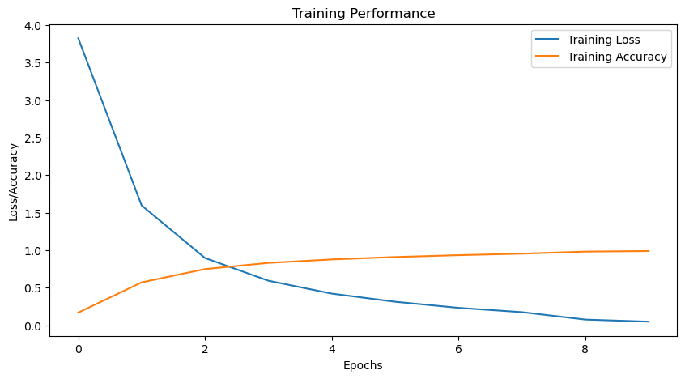

```
Test Loss: 0.3425 Acc: 0.9050
                                                        precision    recall  f1-score   support

                            AM General Hummer SUV 2000       0.95      0.93      0.94        44
                             Acura Integra Type R 2001       0.87      0.95      0.91        42
                                   Acura RL Sedan 2012       0.66      0.91      0.76        32
                                   Acura TL Sedan 2012       0.88      0.84      0.86        43
                                  Acura TL Type-S 2008       0.98      1.00      0.99        41
                                  Acura TSX Sedan 2012       0.95      0.90      0.92        40
                              Acura ZDX Hatchback 2012       0.97      0.87      0.92        39
              Aston Martin V8 Vantage Convertible 2012       0.81      0.87      0.84        45
                    Aston Martin V8 Vantage Coupe 2012       0.94      0.80      0.87        41
                  Aston Martin Virage Convertible 2012       0.95      0.64      0.76        33
                        Aston Martin Virage Coupe 2012       0.74      0.92      0.82        38
                                   Audi 100 Sedan 1994       0.71      0.72      0.72        40
                                   Audi 100 Wagon 1994       0.81      0.71      0.76        42
                                    Audi A5 Coupe 2012       0.70      0.93      0.80        41
                                    Audi R8 Coupe 2012       0.93      0.93      0.93        42
                            Audi RS 4 Convertible 2008       0.89      0.92      0.90        36
                                    Audi S4 Sedan 2007       0.91      0.96      0.93        45
                                    Audi S4 Sedan 2012       0.90      0.72      0.80        39
                              Audi S5 Convertible 2012       0.92      0.81      0.86        42
                                    Audi S5 Coupe 2012       0.76      0.62      0.68        42
                                    Audi S6 Sedan 2011       0.90      0.96      0.93        46
                                Audi TT Hatchback 2011       0.51      0.70      0.59        40
                                 Audi TT RS Coupe 2012       0.82      0.74      0.78        38
                                   Audi TTS Coupe 2012       0.70      0.55      0.61        42
                                    Audi V8 Sedan 1994       0.76      0.81      0.79        43
                         BMW 1 Series Convertible 2012       0.97      0.86      0.91        35
                               BMW 1 Series Coupe 2012       0.91      0.95      0.93        41
                               BMW 3 Series Sedan 2012       0.80      0.85      0.82        41
                               BMW 3 Series Wagon 2012       0.93      0.93      0.93        41
                         BMW 6 Series Convertible 2007       0.87      0.77      0.82        44
                         BMW ActiveHybrid 5 Sedan 2012       0.91      0.91      0.91        34
                                     BMW M3 Coupe 2012       0.91      0.98      0.94        43
                                     BMW M5 Sedan 2010       0.85      0.95      0.90        41
                               BMW M6 Convertible 2010       0.65      0.90      0.76        40
                                       BMW X3 SUV 2012       0.97      0.97      0.97        38
                                       BMW X5 SUV 2007       0.95      0.95      0.95        41
                                       BMW X6 SUV 2012       0.98      0.95      0.96        42
```

[output cut: 148 more lines]

```
                               Toyota 4Runner SUV 2012       0.93      1.00      0.96        40
                               Toyota Camry Sedan 2012       0.91      0.95      0.93        43
                             Toyota Corolla Sedan 2012       1.00      0.81      0.90        43
                               Toyota Sequoia SUV 2012       0.97      0.84      0.90        37
                      Volkswagen Beetle Hatchback 2012       1.00      0.95      0.97        41
                        Volkswagen Golf Hatchback 1991       0.94      1.00      0.97        46
                        Volkswagen Golf Hatchback 2012       0.97      0.91      0.94        43
                                  Volvo 240 Sedan 1993       0.96      0.96      0.96        45
                              Volvo C30 Hatchback 2012       1.00      0.92      0.96        39
                                   Volvo XC90 SUV 2007       0.98      0.93      0.95        43
                         smart fortwo Convertible 2012       1.00      0.97      0.99        40

                                              accuracy                           0.91      7959
                                             macro avg       0.91      0.90      0.90      7959
                                          weighted avg       0.91      0.91      0.91      7959
```

```python
model_ft = train_model(model, criterion, optimizer, scheduler, num_epochs=10)
torch.save(model_ft.state_dict(), 'model_resnet34.pth')
test_accuracy = evaluate_model(model_ft, test_loader, criterion, device, test_dataset)
```

The results of the project show a successful training process of a machine learning model for image classification with the final epoch (epoch 9/9) achieving a training loss of 0.0524 and an accuracy of 98.90%. This shows that the model has learned effectively from the training data, being able to predict the correct labels with high accuracy while minimizing the error (loss).